# DSW_2Assignment4

Data Science Workshop-2 (CSE 2196) ASSIGNMENT-4(LOGISTIC REGRESSION, KNN)

1. Write down the prediction function and cost function and the corresponding python code in the context for logistic regression.

```
[ 1.   2.  -0.8  2.5  3.   2.5]
```

```
array([0.73105858, 0.88079708, 0.31002552, 0.92414182, 0.95257413,
       0.92414182])
```

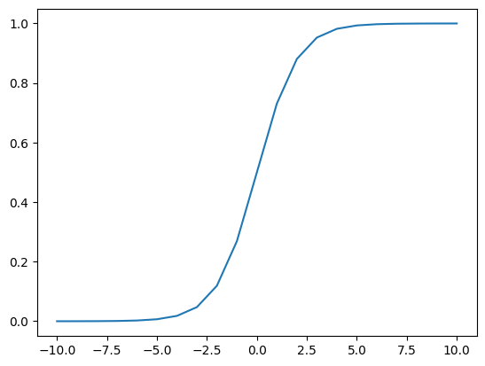

```python
#predict function
import numpy as np
import matplotlib.pyplot as plt
def sigmoid(z):
    g=1.0/(1.0+np.exp(-z))
    return g
sigmoid(1)

x=np.arange(-10,11)
y=sigmoid(x)
plt.plot(x,y)
def predict_logistic(x,w,b):
    return sigmoid(x@w+b)
x=np.array([[0.5,1.5],[1,2],[0.1,0.1],[3,0.5],[2,2],[1,2.5]])
w=np.array([1,1])
b=np.array([-1])
print(x@w+b)
predict_logistic(x,w,b)
```

```python
def compute_cost_logistic(x,y,w,b):
    m=x.shape[0]
    cost=0.0
    for i in range(m):
        z_i=np.dot(x[i],w)+b
        f_wb_i=sigmoid(z_i)
        cost+= -y[i]*np.log(f_wb_i)-(1-y[i])*np.log(1-f_wb_i)
    cost=cost/m
    return cost
y=np.array([0,0,0,1,1,1])
compute_cost_logistic(x,y,w,b)
```

```
array([0.66960953])
```

2. Define types of logistic regression.

On the basis of the categories, Logistic Regression can be classified into three types:

1.Binomial: In binomial Logistic regression, there can be only two possible types of the dependent variables, such as 0 or 1, Pass or Fail, etc.

2.Multinomial: In multinomial Logistic regression, there can be 3 or more possible unordered types of the dependent variable, such as “cat”, “dogs”, or “sheep”

3.Ordinal: In ordinal Logistic regression, there can be 3 or more possible ordered types of dependent variables, such as “low”, “Medium”, or “High”.

3. List the difference between linear regression and logistic regression.

LINEAR REGRESSION Linear Regression is a supervised regression model.

Equation of linear regression:

y = a0 + a1x1 + a2x2 + … + aixi

Here,

y = response variable xi = ith predictor variable ai = average effect on y as xi increases by 1

In Linear Regression, we predict the value by an integer number. Here no activation function is used. Here no threshold value is needed. Here we calculate Root Mean Square Error(RMSE) to predict the next weight value. Here dependent variable should be numeric and the response variable is continuous to value.

It is based on the least square estimation. Here when we plot the training datasets, a straight line can be drawn that touches maximum plots. Linear regression is used to estimate the dependent variable in case of a change in independent variables. For example, predict the price of houses. Linear regression assumes the normal or gaussian distribution of the dependent variable.

LOGISTIC REGRESSION Logistic Regression is a supervised classification model.

Equation of logistic regression

y(x) = e(a0 + a1x1 + a2x2 + … + aixi) / (1 + e(a0 + a1x1 + a2x2 + … + aixi))

Here,

y = response variable xi = ith predictor variable ai = average effect on y as xi increases by 1

In Logistic Regression, we predict the value by 1 or 0.

Here activation function is used to convert a linear regression equation to the logistic regression equation Here a threshold value is added. Here we use precision to predict the next weight value. Here the dependent variable consists of only two categories. Logistic regression estimates the odds outcome of the dependent variable given a set of quantitative or categorical independent variables.

It is based on maximum likelihood estimation. Any change in the coefficient leads to a change in both the direction and the steepness of the logistic function. It means positive slopes result in an S-shaped curve and negative slopes result in a Z-shaped curve. Whereas logistic regression is used to calculate the probability of an event. For example, classify if tissue is benign or malignant. Logistic regression assumes the binomial distribution of the dependent variable.

Applications of linear regression:

Financial risk assessment Business insights Market analysis Applications of logistic regression:

Medicine Credit scoring Hotel Booking Gaming Text editing

4. Let you have given the following dataset:

```python
def compute_gradient_logistic(x, y, w, b):
    """
    Computes the gradient of the logistic loss function with respect to the
    weights and bias.

    Inputs:
        x: A numpy array of shape (m, n) representing m training examples,
            where each example is a vector of n features.
        y: A numpy array of shape (m,) representing the labels for the m
            training examples, where y[i] is the label for x[i].
        w: A numpy array of shape (n,) representing the weights for each
            feature.
        b: A scalar representing the bias term.

    Returns: A tuple (dw, db) where dw is a numpy array of shape (n,)
             representing the gradient of the loss with respect to the
             weights, and db is a scalar representing the gradient of the
             loss with respect to the bias.
    """
    m, n = x.shape
    print(m,n)
    dw = np.zeros(n)
    print(dw)
    db = 0.0
    for i in range(m):
        z = np.dot(x[i],w)+b
        a = sigmoid(-z)
        dw = dw + (a - y[i]) * x[i]
        db = db + (a - y[i])
    dw = dw / m
    db = db / m
    return dw, db

# Example usage
x = np.array([[0.5, 1.5], [1, 2], [0.1, 0.1], [3, 0.5], [2, 2], [1, 2.5]])
y = np.array([2, 3, 1, 4, 3, 3])
w = np.array([0, 0, 0, 1, 1, 1])
b = 1
dw,db = compute_gradient_logistic(x, y, w, b)
print(dw,db)
```

```
6 2
[0. 0.]
```

[output not shown]

```python
import numpy as np
from sklearn.linear_model import LogisticRegression

# Given dataset
X = np.array([[0.5, 1],
              [1, 2],
              [1.5, 2.5],
              [2, 3]])
y = np.array([0, 0, 1, 1])

# Create and fit logistic regression model
model = LogisticRegression()
model.fit(X, y)

# Print the coefficients and intercept
print("Coefficients (beta_1, beta_2):", model.coef_)
print("Intercept (beta_0):", model.intercept_)
```

```
Coefficients (beta_1, beta_2): [[0.57859216 0.69232651]]
Intercept (beta_0): [-2.2062064]
```

5. Explain K-Nearest Neighbor (KNN) algorithm

The K-Nearest Neighbors (KNN) algorithm is a simple yet powerful supervised machine learning algorithm used for classification and regression tasks. It's a non-parametric method, meaning it makes no assumptions about the underlying data distribution.

Here's how it works:

1. Training Phase: During the training phase, KNN stores all the available data points and their corresponding labels (for classification) or values (for regression). This phase simply involves storing the data, making KNN a lazy learner.
2. Prediction Phase:
   - For classification: When a new, unlabeled data point is presented, KNN calculates the distances between this point and all the points in the training dataset.
   - For regression: Instead of labels, KNN calculates the distances between the new data point and all the points in the training dataset, and then predicts the average of the values of the K nearest neighbors.
3. Selecting Neighbors: KNN then selects the K nearest neighbors (data points) to the new data point based on some distance metric (e.g., Euclidean distance, Manhattan distance, etc.). The most common choice is Euclidean distance, but it can vary depending on the problem.
4. Majority Voting (for Classification): In the classification task, once the K nearest neighbors are identified, KNN performs majority voting to assign a class label to the new data point. The class label with the highest frequency among the K neighbors is assigned to the new data point.
5. Regression (for Regression): In regression, the predicted value for the new data point is simply the average of the values of its K nearest neighbors.
6. Choosing the Value of K: The value of K is a hyperparameter that needs to be specified before applying the KNN algorithm. Choosing an appropriate value for K is crucial and can significantly impact the performance of the algorithm. A small value of K leads to a highly flexible model, which might be prone to noise, while a large value of K leads to a smoother decision boundary, but might not capture local patterns well.
7. Distance Metrics: The choice of distance metric can also affect the performance of the KNN algorithm. Common distance metrics include Euclidean distance, Manhattan distance, Minkowski distance, and Hamming distance, among others.

KNN is relatively easy to implement and understand, making it a popular choice for beginners and for baseline performance in more complex tasks. However, its main drawbacks include high computational cost during prediction, especially for large datasets, and sensitivity to the choice of K and the distance metric.

6. How do you choose the optimal k for KNN model?

Choosing the optimal value of ( k ) for a K-Nearest Neighbors (KNN) model involves finding a balance between bias and variance, as well as considering the characteristics of your dataset. Here are several methods commonly used to choose the optimal ( k ):

1. **Brute Force Search**: The simplest method is to try different values of ( k ) and evaluate the performance of the model using cross-validation. You can start with a small value of ( k ) and gradually increase it until you notice diminishing returns in performance.
2. **Cross-Validation**: Use techniques like ( k )-fold cross-validation to evaluate the model's performance for different values of ( k ). This allows you to estimate how well the model will generalize to unseen data for each ( k ) value.
3. **Grid Search**: Perform a grid search over a range of ( k ) values and other hyperparameters (if applicable) to find the combination that yields the best performance. This involves evaluating the model's performance for every possible combination of hyperparameters within predefined ranges.
4. **Elbow Method**: Plot the model's performance (e.g., accuracy, error rate) against different values of ( k ). Look for the point where the performance starts to plateau. This point is often referred to as the "elbow" and represents a good balance between bias and variance.
5. **Distance-Based Methods**: Consider using distance-based techniques to determine an appropriate value for ( k ). For example, you can calculate the distance between each data point and its ( k ) nearest neighbors, then analyze the distribution of distances to determine an optimal ( k ) value.
6. **Domain Knowledge**: Take into account any prior knowledge or domain-specific insights that could help guide the selection of ( k ). For example, if you know that the underlying data distribution is noisy, you might choose a smaller value of ( k ) to reduce the impact of outliers.
7. **Use Case**: Consider the specific requirements of your use case. For example, if you prioritize model interpretability, you might choose a smaller ( k ) value to have a simpler decision boundary.
8. **Experimentation**: Lastly, don't hesitate to experiment with different values of ( k ) and observe how they affect the model's performance. Sometimes, the optimal value of ( k ) may vary depending on the characteristics of the dataset and the problem at hand.

Overall, choosing the optimal ( k ) for a KNN model involves a combination of empirical evaluation, domain knowledge, and experimentation to find the best balance between bias and variance for your specific task.

7. Suppose you have given the following dataset:

x1 x2 y

0.5 1 0

1 1 0

2 2.5 1

2.5 3 1

3 3 1 Where x1, x2 are independent variable and y is dependent variable. Predict the class for [1.5,1] for k=2,3 respectively.

To predict the class for the data point ([1.5, 1]) using the K-Nearest Neighbors (KNN) algorithm, we follow these steps:

1. **Calculate Distances**: Calculate the Euclidean distance between ([1.5, 1]) and each point in the dataset.
2. **Find Nearest Neighbors**: Select the (k) data points from the dataset that are closest to ([1.5, 1]) based on the calculated distances.
3. **Majority Voting**: For each value of (k), determine the majority class among the (k) nearest neighbors.
4. **Prediction**: Assign the class label based on the majority class.

Let's calculate this step by step:

So, for (k = 2), the predicted class is 0, and for (k = 3), the predicted class is also 0.

8. If the dataset is imbalance, then can the prediction by KNN be bias? Explain with an example.

Yes, the prediction by K-Nearest Neighbors (KNN) can be biased if the dataset is imbalanced. Imbalanced datasets occur when one class is significantly more prevalent than the others. In such cases, KNN tends to predict the majority class more frequently, leading to biased predictions.

Let's illustrate this with an example:

Suppose we have a dataset of credit card transactions where fraudulent transactions are rare compared to legitimate ones. The dataset contains 99% legitimate transactions (class 0) and only 1% fraudulent transactions (class 1). This is a classic example of class imbalance.

Now, let's say we want to use KNN to predict whether a new transaction is fraudulent or not. If we use a small value of ( k ), such as ( k = 1 ), the algorithm will only consider the nearest neighbor to the new transaction. In this imbalanced dataset, it's highly likely that the nearest neighbor will belong to the majority class (legitimate transactions). As a result, the algorithm will tend to predict the majority class (class 0) for most new transactions, regardless of their actual class.

Even if we use larger values of ( k ), such as ( k = 5 ) or ( k = 10 ), the majority of the nearest neighbors may still belong to the majority class due to the imbalance in the dataset. As a result, the predictions may still be biased towards the majority class.

In such cases, the algorithm may achieve high accuracy simply by always predicting the majority class, but it fails to detect the minority class (fraudulent transactions), which is often the more critical class to identify.

To address this bias in KNN predictions for imbalanced datasets, various techniques can be employed, such as:

1. **Resampling Techniques**: Oversampling the minority class or undersampling the majority class to balance the dataset.
2. **Weighted KNN**: Assigning weights to the neighbors based on their class frequencies.
3. **Cost-sensitive Learning**: Modifying the cost function to penalize misclassifications of the minority class more heavily.
4. **Using Different Distance Metrics**: Employing distance metrics that are less sensitive to class imbalance.
5. **Ensemble Methods**: Combining predictions from multiple KNN models trained on balanced subsets of the data.

By employing these techniques, we can mitigate the bias in KNN predictions and improve the model's ability to accurately classify instances from both minority and majority classes in imbalanced datasets.

```python
import numpy as np
from sklearn.model_selection import train_test_split
from sklearn.neighbors import KNeighborsClassifier
from sklearn.metrics import classification_report


# Generating a synthetic imbalanced dataset
np.random.seed(42)
X_majority = np.random.rand(9900, 2)  # Majority class (legitimate transactions)
X_minority = np.random.rand(100, 2)   # Minority class (fraudulent transactions)
y_majority = np.zeros(9900)           # Class labels for majority class (0)
y_minority = np.ones(100)             # Class labels for minority class (1)

# Combining majority and minority class data
X = np.vstack((X_majority, X_minority))
y = np.concatenate((y_majority, y_minority))

# Splitting the dataset into training and testing sets
X_train, X_test, y_train, y_test = train_test_split(X, y, test_size=0.2, random_state=42)

# Before SMOTE: Training a KNN classifier
knn_before_smote = KNeighborsClassifier(n_neighbors=5)
knn_before_smote.fit(X_train, y_train)
y_pred_before_smote = knn_before_smote.predict(X_test)

# Evaluating KNN classifier
print("KNN Classifier Performance :")
print(classification_report(y_test, y_pred_before_smote))
```

```
KNN Classifier Performance :
              precision    recall  f1-score   support

         0.0       0.99      1.00      0.99      1979
         1.0       0.00      0.00      0.00        21

    accuracy                           0.99      2000
   macro avg       0.49      0.50      0.50      2000
weighted avg       0.98      0.99      0.98      2000
```